# 12 · Consumo de APIs REST

## Consumo de APIs REST

[figure not shown]

12 · HTTP · EVIDENCIA EXTERNA

Consumo de  
APIs REST

**De una petición HTTP a un control reproducible**

Python, Banco Central Europeo y control de divisas.

Operaciones ficticias · Fuente pública de referencia

## Objetivos del bloque

- Leer una petición y una respuesta HTTP.
- Consumir una API pública con Python y validar su contrato.
- Tratar autenticación, paginación, límites y fallos transitorios.
- Convertir una referencia cambiaria en un control auditable.

**Pregunta del Observatorio.** ¿Qué conversiones USD→EUR requieren revisar el justificante?

## 1 · Qué expone una API

Una API publica un contrato para que un programa acceda a datos o capacidades de otro sistema. El contrato concreta rutas, parámetros, formatos, permisos y errores.

**Ejemplo.** El Observatorio pide cotizaciones al BCE y recibe observaciones fechadas. Su código interpreta el resultado según el contrato.

## Qué aporta REST

REST es un estilo arquitectónico. En una API HTTP orientada a recursos, una URI identifica el recurso y una representación transmite su estado.

- **Recurso** · colección de operaciones.
- **Identificador** · `/operaciones`.
- **Representación** · JSON con registros y paginación.
- **Sin estado de sesión en la petición** · cada solicitud lleva el contexto necesario para procesarla.

## Anatomía de un intercambio

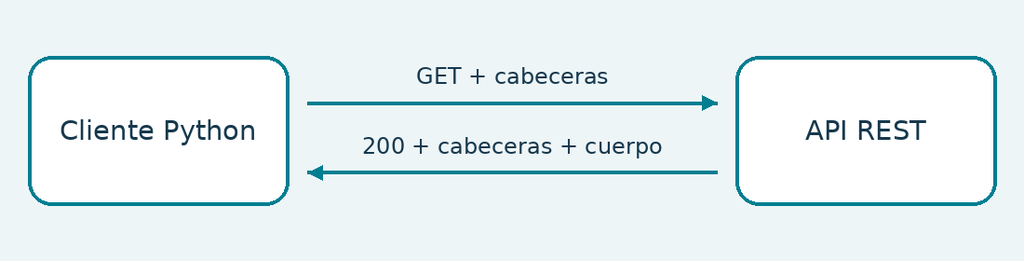

El cliente envía GET y cabeceras. La API devuelve código, cabeceras y cuerpo.

**Petición** · método, URI, cabeceras y, cuando corresponde, cuerpo.

**Respuesta** · código de estado, cabeceras y, cuando corresponde, cuerpo.

## Ruta, filtros y codificación

```
https://ejemplo.invalid/operaciones?page=2&limit=2
|_____ origen _______| |__ ruta ___| |____ consulta ____|
```

- La ruta selecciona una colección o un recurso.
- La consulta aplica filtros o paginación según el contrato.
- `urlencode` codifica los valores antes de concatenarlos.

## Métodos, seguridad semántica e idempotencia

| Método | Uso típico | Seguro | Idempotente |
| --- | --- | --- | --- |
| GET | Leer | Sí | Sí |
| POST | Crear o iniciar una acción | No | No en general |
| PUT | Reemplazar la representación | No | Sí |
| PATCH | Modificar parte del recurso | No | Depende del contrato |
| DELETE | Eliminar | No | Sí |

## Leer las cabeceras

| Cabecera | Dónde | Qué expresa |
| --- | --- | --- |
| Accept | Petición | Formatos que admite el cliente |
| Authorization | Petición | Credencial de acceso |
| Content-Type | Respuesta o petición con cuerpo | Formato real del cuerpo |
| Retry-After | Respuesta | Espera sugerida antes de volver |
| ETag | Respuesta | Validador de una representación |

## 2 · Leer el estado HTTP

| Estado | Qué observar | Acción de aula |
| --- | --- | --- |
| 200 | Respuesta con éxito | Validar formato y contenido |
| 204 | Éxito sin contenido | Evitar interpretar JSON vacío |
| 400 | Petición inválida | Corregir parámetros |
| 401 / 403 | Credencial o acceso insuficiente | Revisar autenticación y permisos |
| 404 | Recurso no encontrado | Revisar ruta o identificador |
| 429 | Límite de peticiones | Aplicar espera y presupuesto |
| 502 / 503 / 504 | Fallo transitorio posible | Reintento acotado de GET |

## Qué dice un 200 sobre el dato

```json
{
  "items": [{"id": "OP-001", "importe_usd": "1100.00"}],
  "next_page": 2
}
```

Comprobar el tipo de raíz, los campos, las unidades y las reglas del dominio antes de usar los datos.

## Credenciales y mínimo privilegio

- Usar HTTPS y mantener la verificación de certificados.
- Enviar un token Bearer en `Authorization` si el contrato lo pide.
- En producción, recuperar secretos de un mecanismo autorizado y rotarlos según política.
- Registrar el resultado y el identificador de ejecución, evitando volcar cabeceras sensibles.

## Timeout y presupuesto de espera

`timeout=8` configura un límite para operaciones bloqueantes de red del cliente de aula. Una ejecución con varios intentos puede durar más.

Para $n$ intentos, hay como máximo $n-1$ pausas. Con base $b=1$ s y tope $c=8$ s:

$$w_k=\min(c,b\cdot 2^{k-1})$$

## GIF · El cliente aprende a esperar

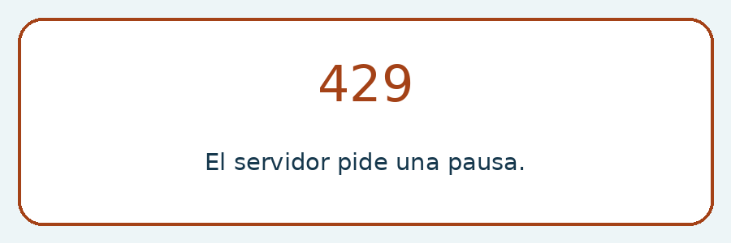

429, pausa solicitada por el servidor y respuesta 200 en el segundo intento.

En el laboratorio, el primer GET recibe `Retry-After: 2`. El segundo devuelve 200.

## Diseñar una política de reintentos

1. Decidir qué operaciones se pueden repetir.
2. Distinguir errores transitorios de errores de contrato.
3. Limitar intentos y respetar la espera del proveedor.
4. Registrar el último fallo y dejar el lote pendiente si se agota el límite.

## 3 · Paginación y cobertura

La primera página puede tener solo dos de cuatro registros. Seguir `next_page` hasta `null`, validando cada lote.

| Control | Fallo que detecta |
| --- | --- |
| Límite de páginas | Consumo inesperado |
| Cursor visitado | Bucle |
| ID único | Solapamiento de páginas |
| Ventana estable | Datos que cambian durante la descarga |

## Cómo reconocer un cambio de contrato

- **Estructura** · cambió el nombre de una columna.
- **Tipo** · una fecha dejó de cumplir el formato esperado.
- **Unidad** · el tipo de cambio corresponde a otra serie.
- **Granularidad** · aparece más de una observación para el mismo día.
- **Cobertura** · faltan observaciones dentro de la ventana pedida.

## 4 · Fuente oficial del BCE

**BCE Data Portal** · API estadística SDMX. Seleccionamos una serie pública de tipos de cambio de referencia del euro.

```
GET /service/data/EXR/D.USD.EUR.SP00.A
    ?startPeriod=2024-01-02&endPeriod=2024-01-06&format=csvdata
```

[Documentación de la consulta de datos](https://data.ecb.europa.eu/help/api/data)

## Leer la clave SDMX

| Posición | Valor | Dimensión |
| --- | --- | --- |
| Flujo | EXR | Tipos de cambio |
| 1 | D | Frecuencia diaria |
| 2 | USD | Moneda observada |
| 3 | EUR | Moneda denominadora |
| 4 | SP00 | Tipo spot |
| 5 | A | Sufijo de la serie |

**Lectura** · cuántos USD corresponden a 1 EUR.

## De la URL a las observaciones

```python
from api_auditoria import get, leer_cotizaciones, url_bce

url = url_bce("2024-01-02", "2024-01-06")
cuerpo, meta = get(url, accept="text/csv")
tipos = leer_cotizaciones(cuerpo)
```

El comando de clase `--en-vivo` comprueba también el tipo de contenido y conserva la respuesta descargada.

## Gráfico · Tipo de referencia del aula

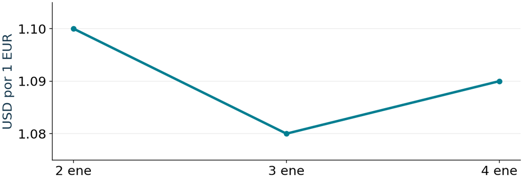

Tres cotizaciones sintéticas. 2 de enero: 1.10; 3 de enero: 1.08; 4 de enero: 1.09 USD por EUR.

**Serie sintética.** Cada punto es una fecha disponible. El eje vertical usa USD por 1 EUR.

## 5 · Modelo de conversión

Sea $r_d$ el tipo en USD por EUR de la fecha $d$ y $U$ el importe en USD.

$$E_{ref}=\operatorname{redondear}_{0.01}(U/r_d)$$
$$\Delta=E_{registrado}-E_{ref}$$

**Ejemplo.** 1080 USD / 1,08 USD por EUR = 1000 EUR. Con 1015 EUR registrados, $\Delta=+15$ EUR.

## Regla de decisión

| Condición | Resultado |
| --- | --- |
| Hay tipo y $\lvert\Delta\rvert\leq0.01$ EUR | Dentro de tolerancia |
| Hay tipo y $\lvert\Delta\rvert>0.01$ EUR | Revisar |
| Falta tipo para la fecha exacta | Sin referencia |

**Frontera** · +0,01 EUR se admite. Con fecha ausente se conservan esperado y diferencia como `null`.

## Cuatro operaciones de aula

| Operación | EUR registrados | EUR referencia | Diferencia | Estado |
| --- | --- | --- | --- | --- |
| OP-001 | 1000,00 | 1000,00 | 0,00 | Dentro |
| OP-002 | 1015,00 | 1000,00 | +15,00 | Revisar |
| OP-003 | 100,01 | 100,00 | +0,01 | Dentro |
| OP-004 | 455,00 | — | — | Sin referencia |

## Gráfico · Distribución del control

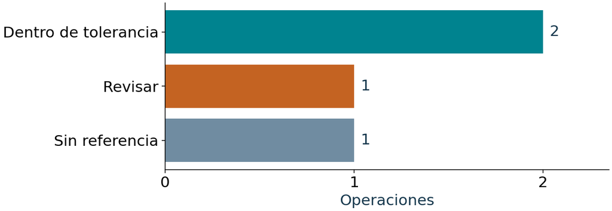

Dos operaciones dentro de tolerancia, una para revisar y una sin referencia.

**Cobertura.** Tres de cuatro operaciones tienen referencia. Una de esas tres supera la tolerancia.

## 6 · Evidencia reproducible

| Pieza | Para qué sirve |
| --- | --- |
| CSV de respuesta | Reinterpretar la entrada recibida |
| URL y fecha UTC en vivo | Identificar consulta y momento |
| SHA-256 del CSV | Comparar el fichero conservado con su huella |
| Criterio y tolerancia | Explicar la decisión |
| ID y estado por operación | Trazar la revisión |

## Ejecutar la práctica

```bash
python api_auditoria.py evidencias_aula
python api_auditoria.py evidencias_bce --en-vivo
```

El primer comando usa datos sintéticos. El segundo conserva la respuesta pública y puede producir diferencias distintas. Usa un directorio nuevo en cada ejecución.

## Del control al informe

El JSON produce dos colas para el Observatorio: diferencias a revisar y operaciones pendientes de referencia.

- El bloque 10 puede consumir un resumen por estado y su cobertura.
- El bloque 11 puede presentar cifras y excepciones.
- La extracción se conserva junto al criterio que generó el control.

## Práctica autónoma · Ejercicios 1 a 5

1. Construir e inspeccionar una URL SDMX.
2. Recuperar la segunda página de operaciones.
3. Diferenciar petición inválida de ruta inexistente.
4. Leer un recurso protegido con un token de aula.
5. Registrar la pausa de un reintento por 429.

## Práctica autónoma · Ejercicios 6 a 10

6. Completar la paginación y probar su límite.
7. Rechazar una cotización que pertenece a otra serie.
8. Aplicar Decimal, redondeo y tolerancia.
9. Gestionar una operación sin referencia.
10. Generar evidencias y verificar su integridad.

## Referencias de consulta

- [BCE Data Portal · API y recursos](https://data.ecb.europa.eu/help/api/overview)
- [BCE Data Portal · Consultas de datos](https://data.ecb.europa.eu/help/api/data)
- [BCE · Tipos de referencia del euro](https://www.ecb.europa.eu/stats/policy_and_exchange_rates/euro_reference_exchange_rates/html/index.en.html)
- [RFC 9110 · Semántica HTTP](https://www.rfc-editor.org/rfc/rfc9110)
- [Python · urllib.request](https://docs.python.org/3/library/urllib.request.html)
- [Python · decimal](https://docs.python.org/3/library/decimal.html)

**Notas docentes · N para cerrar**